# Single cell RNA-seq data analysis

## Finding differentially expressed genes (cluster biomarkers)

```
# find all markers of cluster 1
cluster1.markers <- FindMarkers(object = pbmc, ident.1 = 1, min.pct = 0.25)
print(x = head(x = cluster1.markers, n = 5))


# find all markers distinguishing cluster 5 from clusters 0 and 3
cluster5.markers <- FindMarkers(object = pbmc, ident.1 = 5, ident.2 = c(0, 3),
                                min.pct = 0.25)
print(x = head(x = cluster5.markers, n = 5))

#also we can perform a pair wise detection
#find markers distiguishing cluster 1 from cluster 2

cluster1_2.markers <- FindMarkers(object = pbmc, ident.1 = 1, ident.2 = 2,
                                  min.pct = 0.25)
```

Now we want to find markers for every cluster

```r
# find markers for every cluster compared to all remaining cells, report only the positive ones

pbmc.markers <- FindAllMarkers(object = pbmc, only.pos = TRUE, min.pct = 0.25,
                               thresh.use = 0.25)

#could be slow

#print top 2 markers names each clusters
pbmc.markers %>% group_by(cluster) %>% top_n(2, avg_logFC)
```

```
## # A tibble: 16 x 7
## # Groups:   cluster [8]
##            p_val avg_logFC pct.1 pct.2     p_val_adj cluster     gene
##            <dbl>     <dbl> <dbl> <dbl>         <dbl>  <fctr>    <chr>
##  1 1.469014e-234  1.148805 0.924 0.482 2.014606e-230       0     LDHB
##  2 3.093964e-129  1.067698 0.662 0.202 4.243063e-125       0     IL7R
##  3  0.000000e+00  3.830954 0.996 0.216  0.000000e+00       1   S100A9
##  4  0.000000e+00  3.786963 0.973 0.122  0.000000e+00       1   S100A8
##  5  0.000000e+00  2.977852 0.936 0.042  0.000000e+00       2    CD79A
##  6 1.055671e-269  2.486019 0.623 0.022 1.447748e-265       2    TCL1A
##  7 8.029765e-207  2.158812 0.974 0.230 1.101202e-202       3     CCL5
##  8 1.118949e-181  2.113428 0.588 0.050 1.534527e-177       3     GZMK
##  9 1.037543e-172  2.278652 0.962 0.137 1.422886e-168       4   FCGR3A
## 10 7.128094e-123  2.154119 1.000 0.316 9.775468e-119       4     LST1
## 11 9.120707e-265  3.334634 0.955 0.068 1.250814e-260       5     GZMB
## 12 6.251673e-192  3.763928 0.961 0.131 8.573544e-188       5     GNLY
## 13 2.510362e-238  2.729243 0.844 0.011 3.442711e-234       6   FCER1A
## 14  7.037034e-21  1.965168 1.000 0.513  9.650588e-17       6 HLA-DPB1
## 15 7.731180e-200  5.020726 1.000 0.010 1.060254e-195       7      PF4
## 16 3.684548e-110  5.944335 1.000 0.024 5.052989e-106       7     PPBP
```

Visualize specific markers

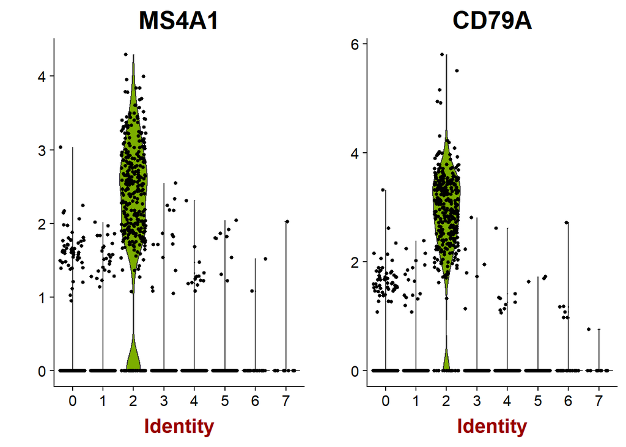

```r
#Violin plot
VlnPlot(object = pbmc, features.plot = c("MS4A1", "CD79A"))
```

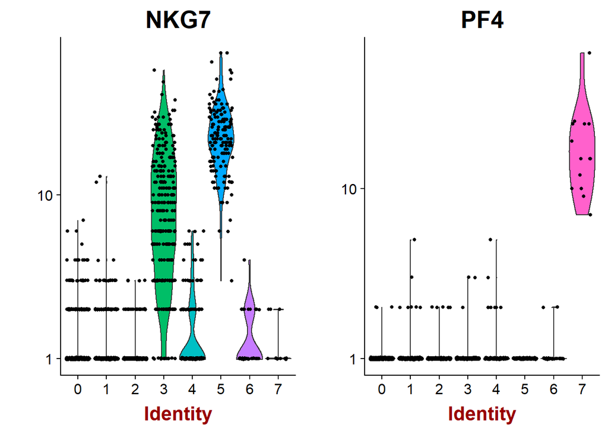

```r
#Or visualize raw counts
VlnPlot(object = pbmc, features.plot = c("NKG7", "PF4"), use.raw = TRUE, y.log = TRUE)
```

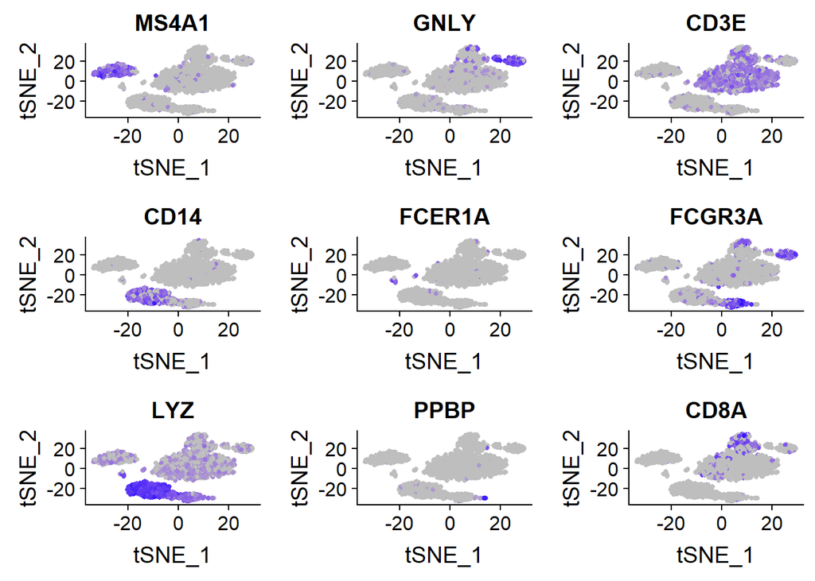

```r
#other method (indicate them in T-SNE plot)
FeaturePlot(object = pbmc, features.plot = c("MS4A1", "GNLY", "CD3E", "CD14",
                                             "FCER1A", "FCGR3A", "LYZ", "PPBP", "CD8A"), cols.use = c("grey", "blue"),
            reduction.use = "tsne")
```

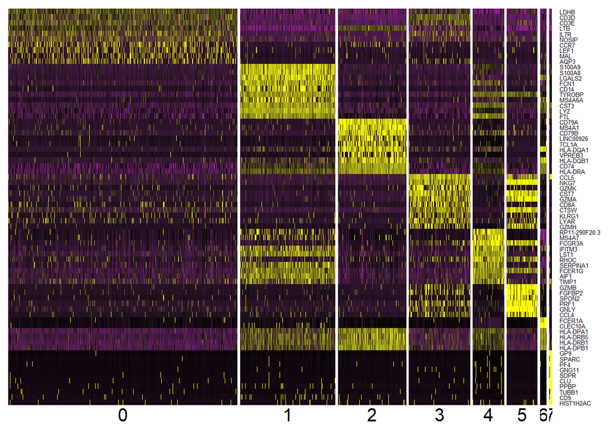

```r
#Or visualize them in heatmap
#draw heatmap for top 10 markers genes from each cluster (all genes if less than 10)
top10 <- pbmc.markers %>% group_by(cluster) %>% top_n(10, avg_logFC)
p<-DoHeatmap(object = pbmc, genes.use = top10$gene, slim.col.label = TRUE, remove.key = TRUE)
p$theme$axis.text.y$size<-5
p
```

## Assigning cell type identity to clusters

In this case of pbmc, we can identify cell types based on known cell markers.

known cell markers

#######################################

# IL7R CD4 T cell #

# CD14, LYZ CD14+ Monocytes #

# MS4A1 B cell #

# CD8A CD8 T cell #

# FCGR3A, MS4A7 FCGR3A+ Monocytes #

# GNLY, NKG7 NK cell #

# FCER1A, CST3 Dendritic Cells #

# PPBP Megakaryocytes #

#######################################

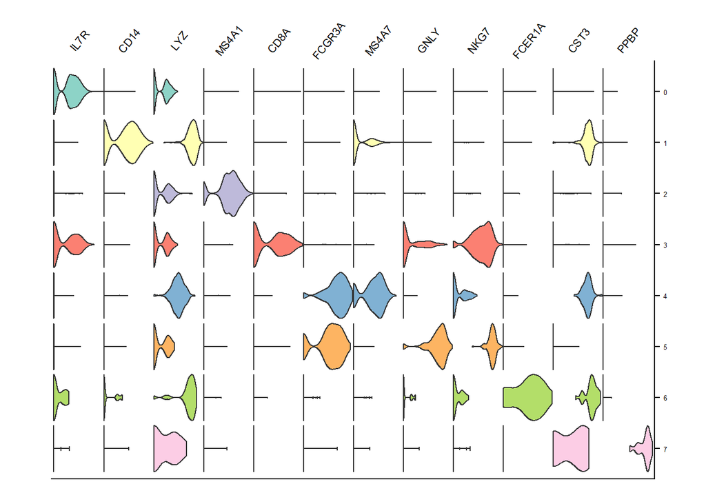

```r
#plot them with violins
identities = pbmc@ident
colors.x = brewer.pal(8, "Set3")
violin.plot.data = get.violin.data(pbmc, c("IL7R","CD14","LYZ","MS4A1","CD8A","FCGR3A","MS4A7","GNLY","NKG7","FCER1A","CST3","PPBP"))

#x11()
ggplot(violin.plot.data, aes(factor(ident),value)) +
  geom_violin(scale="width",adjust=1,trim=TRUE,aes(fill=factor(ident)),show.legend = F) +
  ylab("") + xlab("") +
  coord_flip() +facet_wrap(~ gene,scales = "free_x", ncol = length(levels(violin.plot.data$gene))) +
                theme(strip.text.x = element_text(size=8, angle=50),
                      axis.text.y = element_text(size=5),
                      strip.background = element_blank(),
                      panel.spacing.x = unit(c(-0.2), "lines"),
                      axis.title.x=element_blank(),
                      axis.text.x=element_blank(),
                      axis.ticks.x=element_blank(),
                      plot.margin = unit(c(0.5,0.4,0.5,1.3), "cm")) +
  scale_x_discrete(limits = rev(levels(violin.plot.data$ident)), position = "top") +
  scale_fill_manual(values = colors.x)
```

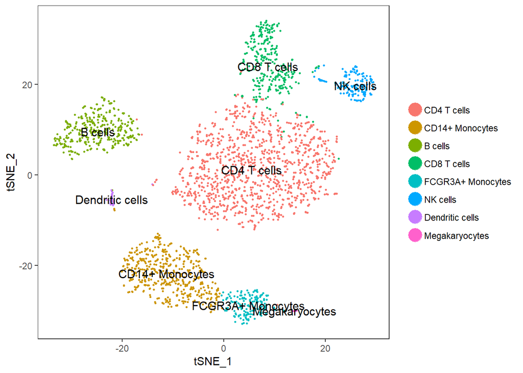

```r
#then we can give clusters new names based on our knowledge, and make a new T-SNE plot
current.cluster.ids <- c(0, 1, 2, 3, 4, 5, 6, 7)
new.cluster.ids <- c("CD4 T cells", "CD14+ Monocytes", "B cells", "CD8 T cells",
                     "FCGR3A+ Monocytes", "NK cells", "Dendritic cells", "Megakaryocytes")
pbmc@ident <- plyr::mapvalues(x = pbmc@ident, from = current.cluster.ids, to = new.cluster.ids)
TSNEPlot(object = pbmc, do.label = TRUE, pt.size = 0.5)
```

## Further subdivisions within cell types

```r
#First let's stash our identities for later
pbmc <- StashIdent(object = pbmc, save.name = "ClusterNames_0.6")

#use a higher resolution
pbmc <- FindClusters(object = pbmc, reduction.type = "pca", dims.use = 1:10,
                     resolution = 0.8, print.output = FALSE)
```

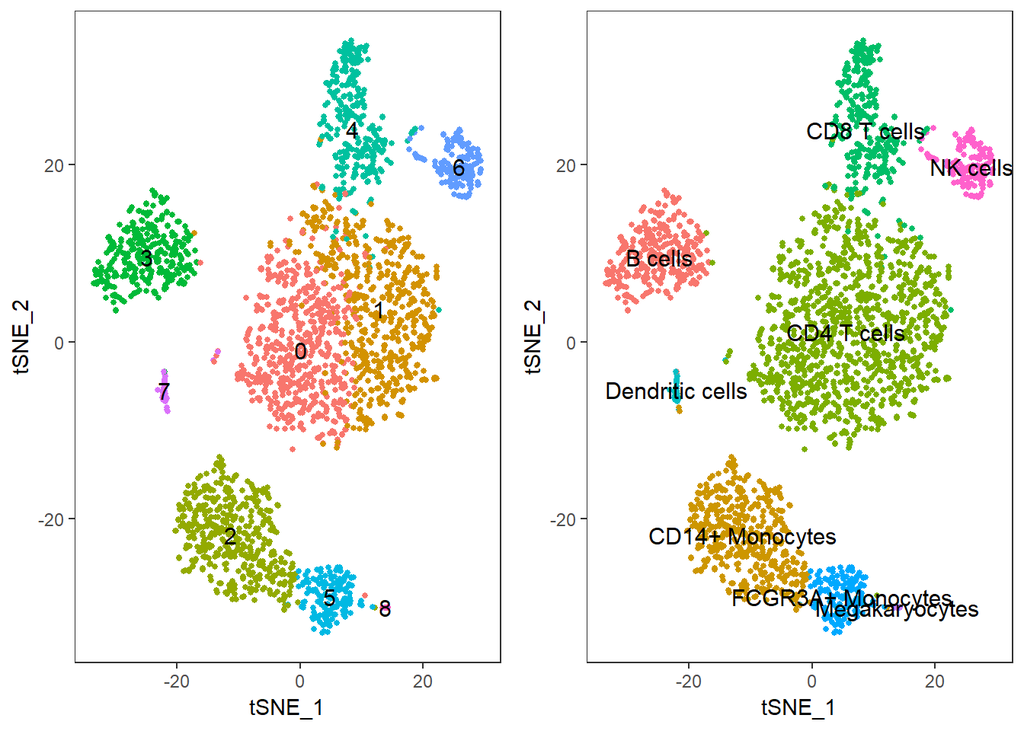

```r
plot1 <- TSNEPlot(object = pbmc, do.return = TRUE, no.legend = TRUE, do.label = TRUE)
plot2 <- TSNEPlot(object = pbmc, do.return = TRUE, group.by = "ClusterNames_0.6",
                  no.legend = TRUE, do.label = TRUE)
plot_grid(plot1, plot2)
```

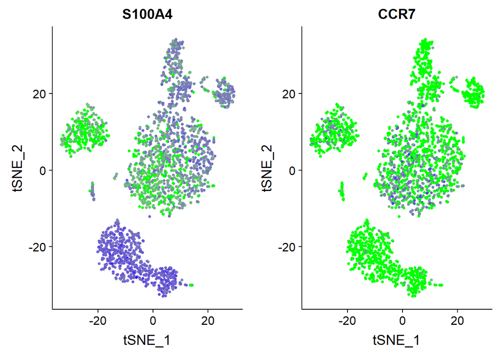

```r
#now we divided CD4 T-cell into two clusters

# Find discriminating markers
tcell.markers <- FindMarkers(object = pbmc, ident.1 = 0, ident.2 = 1)

FeaturePlot(object = pbmc, features.plot = c("S100A4", "CCR7"), cols.use = c("green", "blue"))
```

```r
#The memory/naive split is bit weak

pbmc <- SetAllIdent(object = pbmc, id = "ClusterNames_0.6")
saveRDS(pbmc, file = "~/pbmc3k_final.rds")
```

## Answers

1: Cells with extremly high unique gene counts could be doublets with different cell types.

2: The object of downstream analysis is to identify cell types based on gene expression. So Things influence gene expression besides cell types should be regarded as unwanted sources, e.g. total expression values, cell viability, batch effect ……

3: In brief, t-SNE will consider the relationship between cells which is more good at presenting the differences between cell types, so it’s well applied in single cell visualization.